# Hierarchical normal models in Stan

```r
library("rstan")
library("ggplot2")
library("bayesplot")
library("gridExtra")
source("../helper_funs.R")
```

```r
options(mc.cores = parallel::detectCores())
```

### Load and look at the data

```r
load("kidiq.rda")
head(kidiq)
```

```
##   kid_score mom_hs    mom_iq mom_age
## 1        65      1 121.11753      27
## 2        98      1  89.36188      25
## 3        85      1 115.44316      27
## 4        83      1  99.44964      25
## 5       115      1  92.74571      27
## 6        98      0 107.90184      18
```

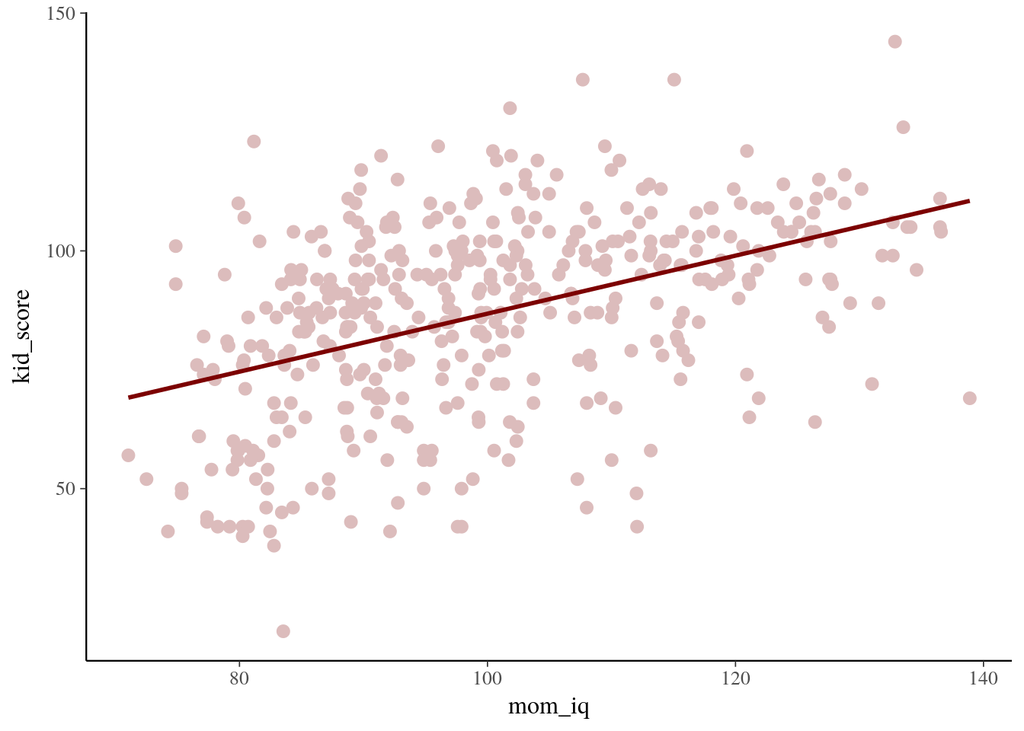

```r
theme_set(bayesplot::theme_default())
p <- ggplot(kidiq,
            aes(
              x = mom_iq,
              y = kid_score
            ))
p1 <- p +
  geom_point(size = 2.5, color = "#DCBCBC") +
  geom_smooth(method = "lm", se = FALSE, color = "#7C0000")

p1
```

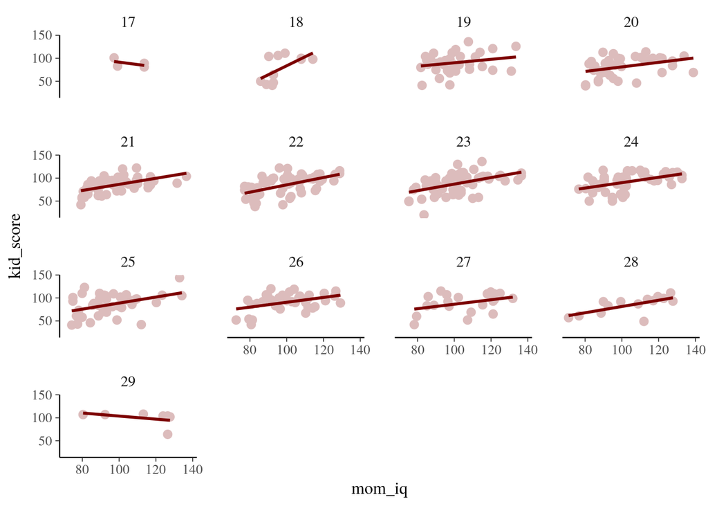

```r
p2 <- p +
  geom_point(size = 2.5, color = "#DCBCBC") +
  geom_smooth(method = "lm", se = FALSE, color = "#7C0000") +
  facet_wrap(~ mom_age)

p2
```

Let’s fit the one-way normal model that we wrote during the presentation. The model:

$$y_n \sim \text{Normal}(\alpha + \theta_{j[n]}, \sigma_y) \\
\theta_j \sim \text{Normal}(0, \sigma_\theta)$$

### Translate Stan code to C++ and compile

```r
mod1 <- stan_model("one-way-normal.stan")
```

[output not shown]

### Fit the model with MCMC

```r
y <- kidiq$kid_score
N <- nrow(kidiq)
idx_J <- as.integer(as.factor(kidiq$mom_age))
J <- length(unique(idx_J))

stan_dat_one_way <- list(N = N, J = J, y = y, idx_J = idx_J)
fit1 <- sampling(mod1, data = stan_dat_one_way, seed = 770619474, iter = 2000)
print(fit1, pars = c("sigma_y", "sigma_theta",'theta'))
```

```
## Inference for Stan model: one-way-normal.
## 4 chains, each with iter=2000; warmup=1000; thin=1;
## post-warmup draws per chain=1000, total post-warmup draws=4000.
##
##              mean se_mean   sd  2.5%   25%   50%   75% 97.5% n_eff Rhat
## sigma_y     20.40    0.01 0.68 19.14 19.93 20.36 20.85 21.78  2595 1.00
## sigma_theta  1.75    0.07 1.15  0.26  0.83  1.54  2.46  4.51   259 1.02
## theta[1]     0.04    0.03 2.01 -4.32 -0.82  0.02  0.89  4.53  4000 1.00
## theta[2]    -0.94    0.06 2.12 -6.26 -1.76 -0.47  0.24  2.38  1233 1.00
## theta[3]     0.68    0.04 1.70 -2.37 -0.27  0.39  1.49  4.70  1949 1.00
## theta[4]    -1.23    0.07 1.86 -5.96 -2.21 -0.75  0.02  1.50   769 1.01
## theta[5]    -0.72    0.04 1.62 -4.65 -1.53 -0.42  0.23  2.09  1413 1.00
## theta[6]    -0.71    0.04 1.57 -4.43 -1.48 -0.42  0.23  1.89  1411 1.00
## theta[7]     0.17    0.02 1.44 -2.80 -0.61  0.10  0.92  3.27  4000 1.00
## theta[8]     1.19    0.06 1.79 -1.52 -0.02  0.75  2.11  5.40   781 1.01
## theta[9]    -0.34    0.03 1.65 -4.24 -1.11 -0.17  0.48  2.82  4000 1.00
## theta[10]    0.89    0.05 1.76 -2.01 -0.18  0.53  1.71  5.19  1431 1.00
## theta[11]    0.33    0.03 1.75 -3.17 -0.54  0.17  1.14  4.23  4000 1.00
## theta[12]   -0.23    0.03 1.81 -4.59 -1.02 -0.10  0.63  3.49  4000 1.00
## theta[13]    0.76    0.05 2.05 -2.74 -0.33  0.38  1.54  6.05  1538 1.00
##
## Samples were drawn using NUTS(diag_e) at Mon Aug 14 15:44:52 2017.
## For each parameter, n_eff is a crude measure of effective sample size,
## and Rhat is the potential scale reduction factor on split chains (at
## convergence, Rhat=1).
```

### Look at the estimates

```r
post_draws <- extract(fit1, pars = c("theta","sigma_theta"), permute=F)
dim(post_draws)
```

```
## [1] 1000    4   14
```

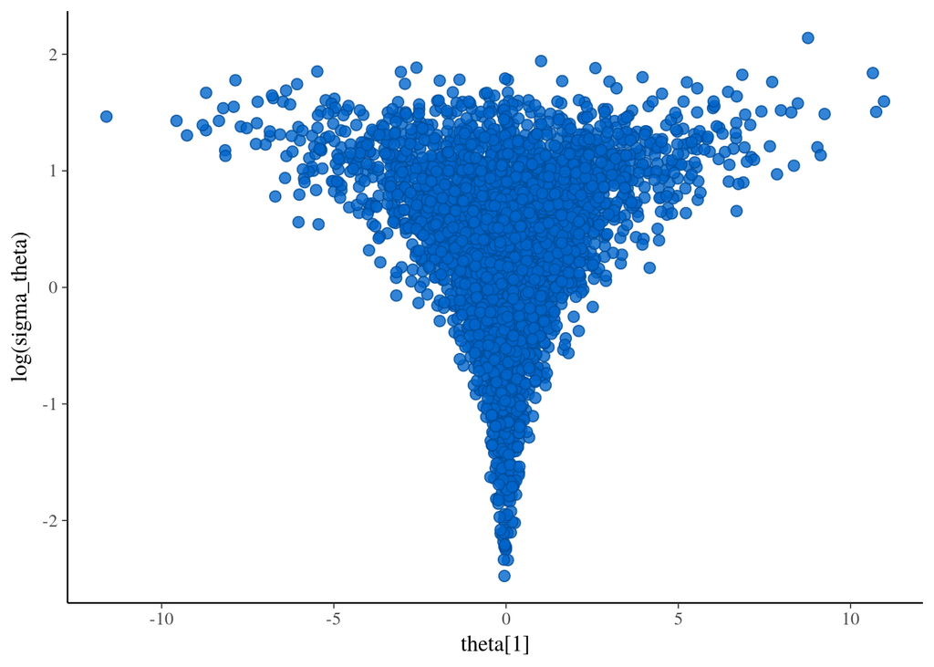

```r
color_scheme_set("brightblue")
mcmc_scatter(post_draws, pars = c("theta[1]", "sigma_theta"),
             transformations = list(sigma_theta = "log"))
```

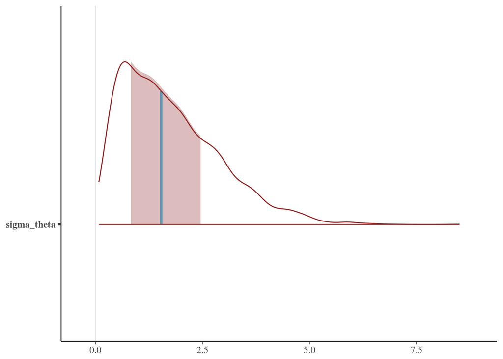

```r
color_scheme_set("mix-red-blue")
mcmc_areas(post_draws, regex_pars = 'sigma_theta')
```

This posterior is a great example of “Neal’s funnel” and is a reason to reparameterize the model. Let’s look at the traceplot of
$$\sigma_{\theta}$$

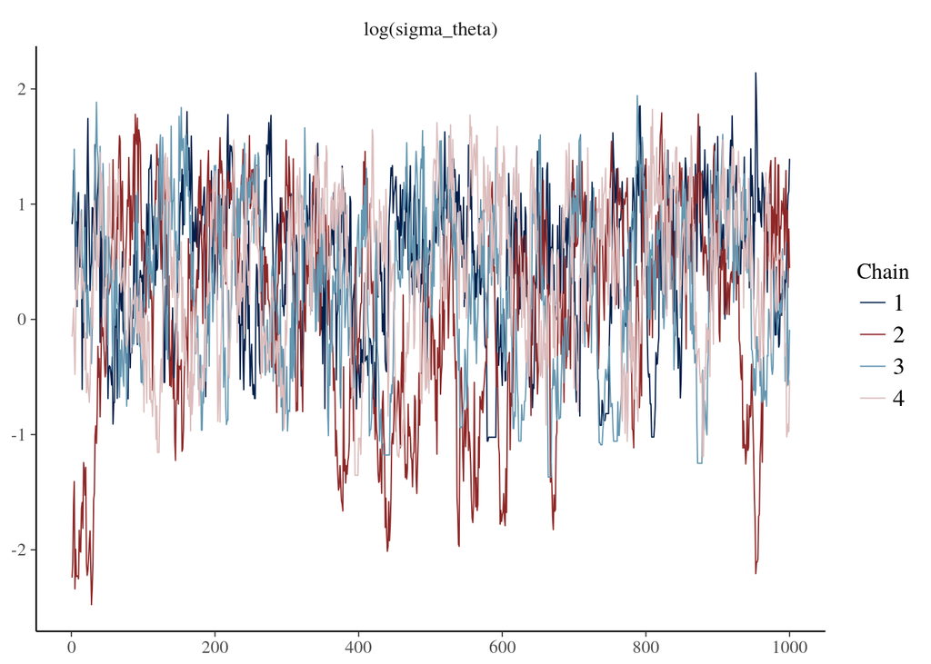

```r
mcmc_trace(post_draws, pars = c("sigma_theta"),
             transformations = list(sigma_theta = "log"))
```

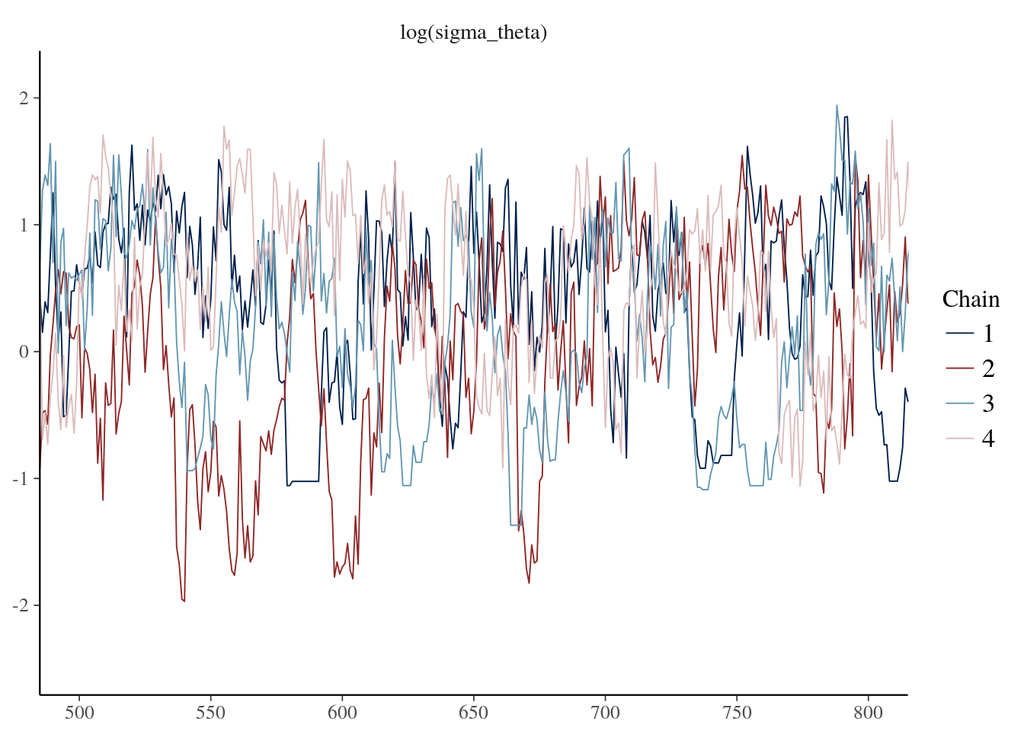

```r
mcmc_trace(post_draws, pars = c("sigma_theta"),
             transformations = list(sigma_theta = "log"), window = c(500,800))
```

Those areas where the traceplot is flat are bad news. Let’s take a look at what Stan is doing when it’s sampling, and it’ll give us a better idea as to how to reparameterize the model to fix the glitch

In our first model, the prior for the random intercept is coded like so:

$$\theta_j \sim \text{Normal}(0, \sigma_\theta)$$

In datasets where the data are weak (or, more formally, when $\sigma_y / \sigma_\theta$ is large), the posterior of $\theta_j$ will be strongly dependent on values of $\sigma_\theta$. That can cause problems for Euclidean Hamiltonian Monte Carlo samplers because we only get one stepsize for the entire posterior and one stepsize won’t be sufficient to explore the posterior in areas where $\sigma_\theta$ is quite small.

We’ll need to use a transformation for $\theta_j$. We can use the fact that if $\eta_j$ is normally distributed:

$$\eta_j \sim \text{Normal}(0, 1)$$

then

$$\alpha + \sigma_\theta \times \eta_j \sim \text{Normal}(\alpha, \sigma_\theta)$$

We can now declare $\theta_j$ in the block and make it a transformation of $\eta_j$:

This is called the non-centered parameterization (NCP for short) for $\theta_j$, and it is likely that most models you code will require all random intercepts and coefficients to have the non-centered parameterization. There is a lot of noise in real data!

The new model is:

$$y_n \sim \text{Normal}(\alpha + \theta_{j[n]}, \sigma_y) \\
\theta_j = \sigma_\theta \times \eta_j \\
\eta_j \sim \text{Normal}(0, 1)$$

Compile the new model:

```r
mod2 <- stan_model("one-way-normal-ncp.stan")
```

[output not shown]

Fit the new model:

```r
fit2 <- sampling(mod2, data = stan_dat_one_way, seed = 770619474, iter = 2000)
```

Examine the dependence between $\sigma_\theta$ and $\eta_j$:

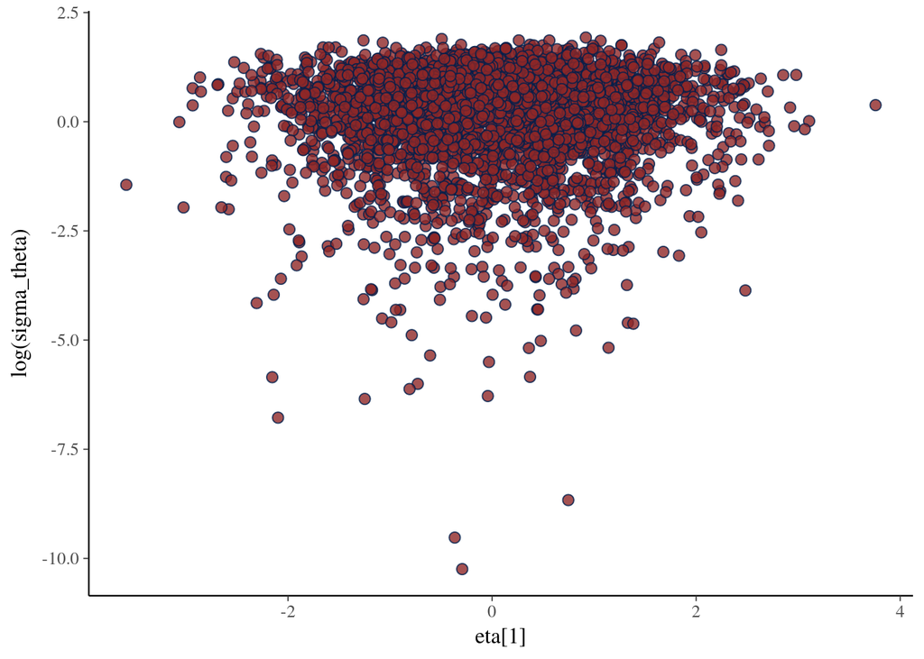

```r
post_draws_2 <- extract(fit2, pars = c("eta","sigma_theta"), permute=F)

mcmc_scatter(post_draws_2, pars = c("eta[1]", "sigma_theta"),
             transformations = list(sigma_theta = "log"))
```

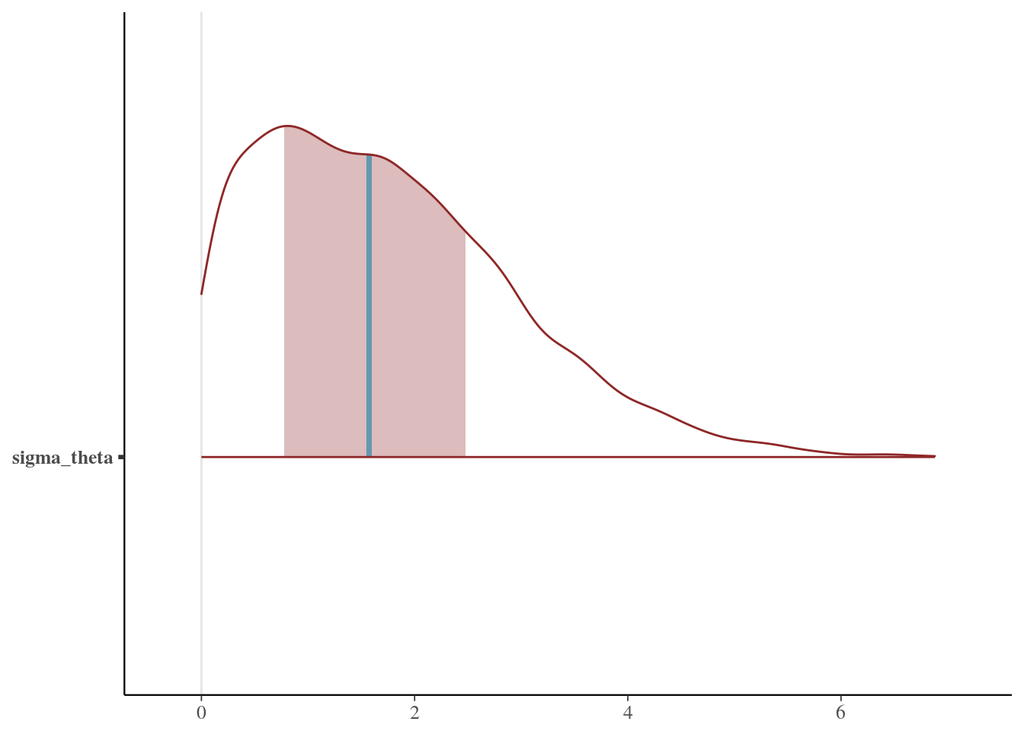

```r
mcmc_areas(post_draws_2, regex_pars = 'sigma_theta')
```

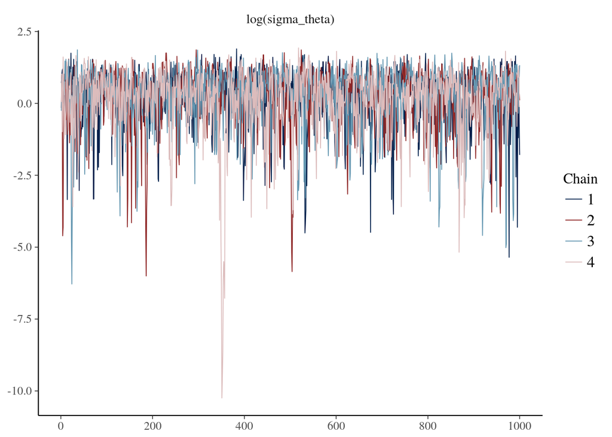

```r
mcmc_trace(post_draws_2, pars = c("sigma_theta"),
             transformations = list(sigma_theta = "log"))
```

## Hierarchical coefficients and a prior for covariance matrices

Ok, let’s add a coefficient to the model, we’ll condition on the IQ of mother to see if this predicts the IQ of the child.

I’m going to center and standardize the variable momiq before I put it into the model. I’m doing this for two reasons:

- I want the prior on alpha to reflect my prior guess at the population average IQ
- Keeping all the parameters in our model at roughly the same scale will speed up our sampling. It should reduce the warmup time which aims to learn the diagonal mass matrix.

```r
X <- (kidiq$mom_iq - mean(kidiq$mom_iq)) / sd(kidiq$mom_iq)
```

The new model will include the same random intercept $\theta$, but we’ll add a random coefficient $\beta$:
$$y_n \sim \text{Normal}(\alpha + \theta_{j[n]} + X_n \times \beta_{j[n]}, \sigma_y) \\
\theta_j = \sigma_\theta \times \eta_j \\
\beta_j = \gamma + \sigma_\beta \times \beta^{\text{std}}_j \\
\eta_j \sim \text{Normal}(0, 1) \\
\beta^{\text{std}}_j \sim \text{Normal}(0, 1)$$

## Motivate the need for correlated random intercept and slopes

```r
mod3 <- stan_model('one-way-normal-ncp-w-hier-slope.stan')
```

[output not shown]

```r
stan_dat_hier_coef <- stan_dat_one_way
stan_dat_hier_coef$X <- X
fit3 <- sampling(mod3, data = stan_dat_hier_coef, iter = 2000, seed = 1301750867)
```

Examine the fit:

```r
print(fit3, pars = c('beta', 'theta','sigma_beta','sigma_theta','gamma'))
```

```
## Inference for Stan model: one-way-normal-ncp-w-hier-slope.
## 4 chains, each with iter=2000; warmup=1000; thin=1;
## post-warmup draws per chain=1000, total post-warmup draws=4000.
##
##              mean se_mean   sd  2.5%   25%   50%   75% 97.5% n_eff Rhat
## beta[1]      9.02    0.02 1.25  6.41  8.29  9.06  9.80 11.47  4000    1
## beta[2]      9.26    0.02 1.27  6.99  8.45  9.23 10.01 11.88  4000    1
## beta[3]      8.86    0.02 1.23  6.21  8.13  8.91  9.65 11.17  4000    1
## beta[4]      8.94    0.02 1.19  6.45  8.20  8.96  9.69 11.21  4000    1
## beta[5]      9.13    0.02 1.14  6.90  8.41  9.11  9.84 11.44  4000    1
## beta[6]      9.34    0.02 1.17  7.17  8.58  9.29 10.04 11.91  4000    1
## beta[7]      9.25    0.02 1.12  7.14  8.51  9.22  9.96 11.51  4000    1
## beta[8]      9.07    0.02 1.13  6.80  8.32  9.07  9.82 11.27  4000    1
## beta[9]      9.09    0.02 1.16  6.82  8.35  9.07  9.82 11.45  4000    1
## beta[10]     8.99    0.02 1.17  6.63  8.25  9.02  9.74 11.24  4000    1
## beta[11]     8.98    0.02 1.22  6.47  8.21  9.00  9.77 11.31  4000    1
## beta[12]     9.07    0.02 1.20  6.68  8.34  9.06  9.82 11.43  4000    1
## beta[13]     8.86    0.02 1.28  6.06  8.10  8.92  9.67 11.24  4000    1
## theta[1]    -0.06    0.03 1.73 -3.82 -0.80 -0.01  0.66  3.74  4000    1
## theta[2]    -0.74    0.03 1.78 -5.34 -1.46 -0.29  0.22  2.09  4000    1
## theta[3]     0.81    0.03 1.62 -1.86 -0.10  0.42  1.58  4.71  4000    1
## theta[4]    -1.25    0.03 1.76 -5.59 -2.14 -0.75 -0.03  1.19  4000    1
## theta[5]    -0.18    0.02 1.37 -3.17 -0.82 -0.07  0.50  2.59  4000    1
## theta[6]    -0.43    0.02 1.35 -3.71 -1.09 -0.21  0.25  2.10  4000    1
## theta[7]     0.11    0.02 1.31 -2.57 -0.56  0.02  0.73  2.96  4000    1
## theta[8]     0.84    0.02 1.55 -1.54 -0.08  0.45  1.60  4.71  4000    1
## theta[9]     0.42    0.02 1.49 -2.36 -0.34  0.19  1.10  4.05  4000    1
## theta[10]    0.82    0.03 1.60 -1.65 -0.11  0.42  1.57  4.88  4000    1
## theta[11]   -0.15    0.02 1.58 -3.69 -0.82 -0.03  0.54  3.15  4000    1
## theta[12]   -0.52    0.03 1.71 -4.80 -1.24 -0.18  0.34  2.62  4000    1
## theta[13]    0.32    0.03 1.84 -3.11 -0.50  0.10  1.04  4.70  4000    1
## sigma_beta   0.69    0.01 0.52  0.03  0.28  0.57  0.99  1.96  4000    1
## sigma_theta  1.52    0.03 1.07  0.08  0.67  1.35  2.17  4.02  1723    1
## gamma        9.06    0.01 0.94  7.21  8.45  9.05  9.67 10.90  4000    1
##
## Samples were drawn using NUTS(diag_e) at Mon Aug 14 15:46:23 2017.
## For each parameter, n_eff is a crude measure of effective sample size,
## and Rhat is the potential scale reduction factor on split chains (at
## convergence, Rhat=1).
```

Extract the draws and make a scatter of slopes vs. coefficients:

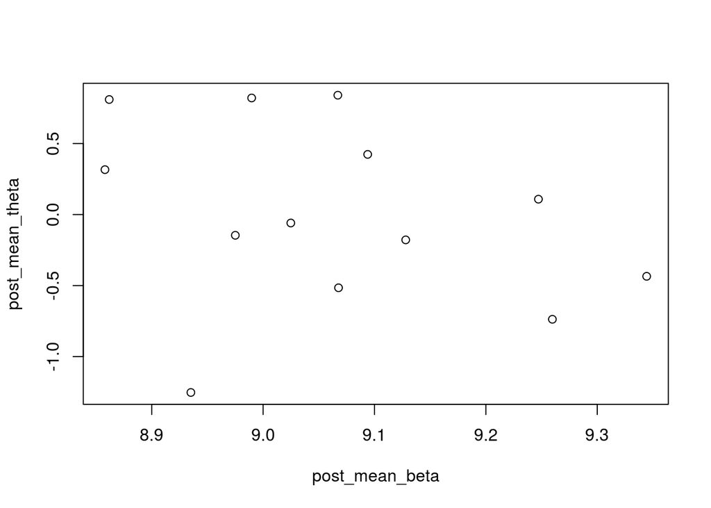

```r
post_draws_3 <- rstan::extract(fit3, pars = c('beta','theta'))
post_mean_beta <- colMeans(post_draws_3$beta)
post_mean_theta <- colMeans(post_draws_3$theta)
plot(post_mean_beta, post_mean_theta)
```

```r
print(cor(post_mean_beta, post_mean_theta))
```

```
## [1] -0.3091238
```

The posterior tells us the random coefficients and intercepts are weakly negatively correlated. We should model that correlation, because the posterior correlation is telling us that we’re not capturing the data generating process in our prior.

We’ll need to do a multivariate version of the NCP. Note that we could try to generate correlated intercepts and coefficients by directly putting a multivariate normal prior over them:

$$\theta \in \mathbb{R}^2 \\
\theta \sim \text{MultiNormal}(0, \Sigma)$$

But this will result in more funnels and problems for EHMC, so we should go straight to the NCP.

$$\Sigma = L \times L^T$$

$$\eta \in \mathbb{R}^2 \\
\eta \sim \text{MultiNormal}(0, I_2) \\
\mu + L \times \eta \sim \text{MultiNormal}(0, \Sigma)$$

### Priors for covariance matrices

What prior should we use for $L$? We could put a prior directly on $\Sigma$, and then use $\texttt{cholesky\_decompose}$, but this’ll add a large overhead because we’ll repeatedly be running a $D^3$ algorithm for each leapfrog step. Instead, we can decompose $\Sigma$:

$$\sigma \in \mathbb{R}^{2} , \Omega \in \mathbb{R}^{2\times2} \\
\Sigma = \text{diag_matrix}(\sigma) \times \Omega \times \text{diag_matrix}(\sigma)$$

### LKJ prior

$Omega$ is a correlation matrix. We can also decompose $\Omega$ into a lower-triangular and an upper triangular matrix, $\Omega = L_\Omega \times L_\Omega^T$, and then we can put a prior on the Cholesky factor of $\Omega$. Stan implements a prior over the Cholesky factor of correlation matrices called the LKJ prior. The density over correlation matrices has a parameter $\nu$. When $\nu \rightarrow \infty$ we get an identiy matrix. $\nu = 1$ yields a uniform prior over correlation matrices, and $0 < \nu < 1$ will favor matrices with extreme correlations. The off-diagonals of $\Omega$ are essentially beta random variables scaled to the interval $[-1, 1]$. When $\nu$ is less than one, we get a ``bathtub’’ density between $[-1,1]$, and as $\nu$ grows larger than one we get a symmetric unimodal density centered on 0, increasing its concentration around zero with increasing $\nu$.

To get a better feel for the LKJ prior, we’ll make some plots.

```r
set.seed(135)

S <- 1e5
dim_LKJ <- 3
draws <- array(0, dim = c(S, 3, dim_LKJ, dim_LKJ))
for (s in 1:S) {
  L_Omega_1 <- chol_lkj(dim_LKJ, nu = 1.0)
  L_Omega_2 <- chol_lkj(dim_LKJ, nu = 3.0)
  L_Omega_3 <- chol_lkj(dim_LKJ, nu = 0.3)
  draws[s,1,,] <- L_Omega_1 %*% t(L_Omega_1)
  draws[s,2,,] <- L_Omega_2 %*% t(L_Omega_2)
  draws[s,3,,] <- L_Omega_3 %*% t(L_Omega_3)
}
```

Plots for the off-diagonal elements of each correlation matrix

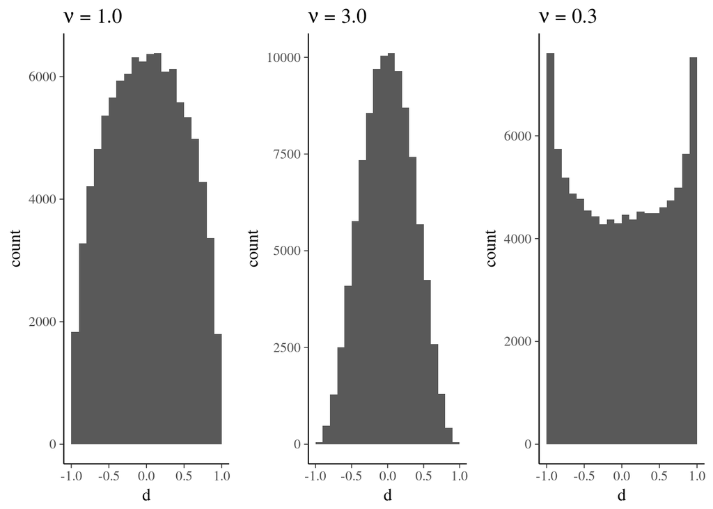

```r
brk_1 <- brk_finder(draws[,1,2,3])
brk_2 <- brk_finder(draws[,2,2,3])
brk_3 <- brk_finder(draws[,3,2,3])

p1 <- ggplot(data = data.frame(s = 1, d = draws[,1,2,3])) +
  geom_histogram(aes(x = d), breaks = brk_1) + xlim(c(-1,1)) + ggtitle(expression(paste(nu,' = 1.0')))
p2 <- ggplot(data = data.frame(s = 2, d = draws[,2,2,3])) +
  geom_histogram(aes(x = d), breaks = brk_2) + xlim(c(-1,1)) + ggtitle(expression(paste(nu,' = 3.0')))
p3 <- ggplot(data = data.frame(s = 3, d = draws[,3,2,3])) +
  geom_histogram(aes(x = d), breaks = brk_3) + xlim(c(-1,1)) + ggtitle(expression(paste(nu,' = 0.3')))

p_lkj <- grid.arrange(p1, p2, p3, ncol = 3)
```

It may be unexpected that $\nu = 1$ doesn’t produce a uniform distribution between $[-1,1]$. This is because $\nu = 1$ produces a uniform density over *correlation matrices*. This equates to matrices whose off-digonal elements are slightly peaked at zero, as required to ensure positive-definiteness over the matrix distribution. We can also see that $\nu = 0.3$ puts more mass on correlation matrices with extreme off-diagonals.

```r
set.seed(135)

S <- 1e5
dim_LKJ <- 5
draws <- array(0, dim = c(S, 3, dim_LKJ, dim_LKJ))
for (s in 1:S) {
  L_Omega_1 <- chol_lkj(dim_LKJ, nu = 1.0)
  L_Omega_2 <- chol_lkj(dim_LKJ, nu = 3.0)
  L_Omega_3 <- chol_lkj(dim_LKJ, nu = 0.3)
  draws[s,1,,] <- L_Omega_1 %*% t(L_Omega_1)
  draws[s,2,,] <- L_Omega_2 %*% t(L_Omega_2)
  draws[s,3,,] <- L_Omega_3 %*% t(L_Omega_3)
}
```

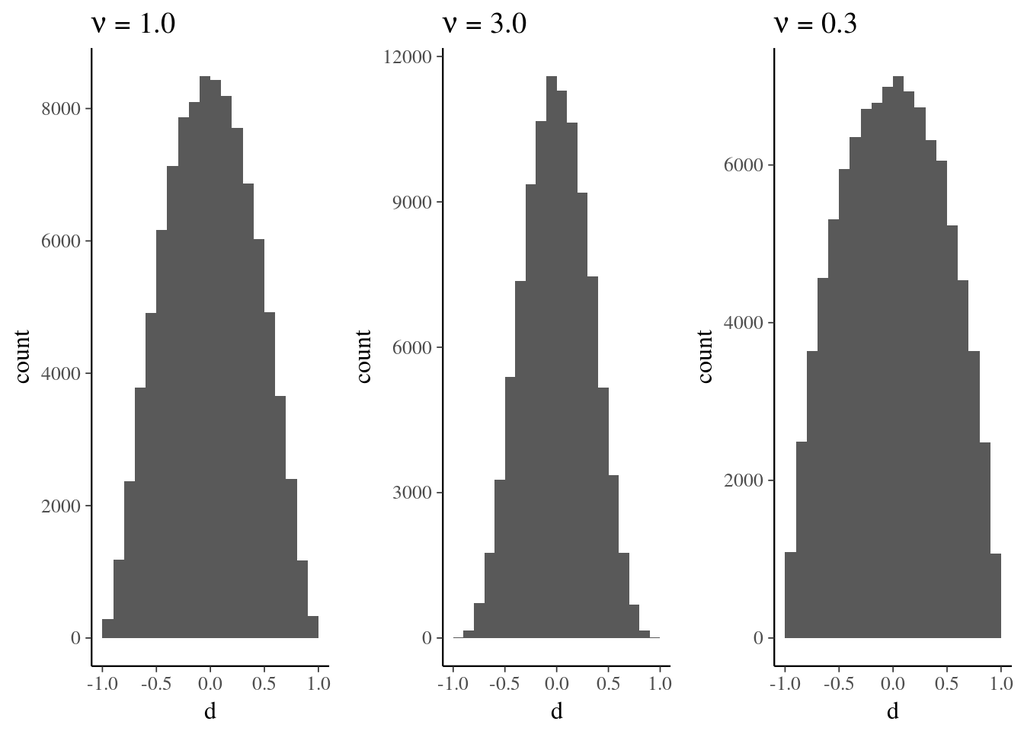

```r
brk_1 <- brk_finder(draws[,1,2,3])
brk_2 <- brk_finder(draws[,2,2,3])
brk_3 <- brk_finder(draws[,3,2,3])

p1 <- ggplot(data = data.frame(s = 1, d = draws[,1,2,3])) +
  geom_histogram(aes(x = d), breaks = brk_1) + xlim(c(-1,1)) + ggtitle(expression(paste(nu,' = 1.0')))
p2 <- ggplot(data = data.frame(s = 2, d = draws[,2,2,3])) +
  geom_histogram(aes(x = d), breaks = brk_2) + xlim(c(-1,1)) + ggtitle(expression(paste(nu,' = 3.0')))
p3 <- ggplot(data = data.frame(s = 3, d = draws[,3,2,3])) +
  geom_histogram(aes(x = d), breaks = brk_3) + xlim(c(-1,1)) + ggtitle(expression(paste(nu,' = 0.3')))

p_lkj <- grid.arrange(p1, p2, p3, ncol = 3)
```

As we move to higher dimensions, the off-diagonal distributions become more peaked at 0 for a fixed value of $\nu$. This makes intuitive sense for a correlation prior. As we compute correlations of more random variables, in the absence of any more information about the variables, it is less likely for any two correlations to be truly high. This is because we’ll be estimating $N$ choose $2$ correlation parameters, which grows quickly as the number of random variables grows. If we wanted to have 10 observations for each parameter in our correlation matrix and we had 50 series, we’d need 12,250 observations.

We’ll fit this model:

$$y_n \sim \text{Normal}(\alpha + \theta^{\text{age}}_{j[n]} + X_n \times \beta_{j[n]}, \sigma_y) \\
\theta^{\text{age}} = \theta[,1] \\
\beta = \gamma + \theta[,2]\\
\theta = (\text{diag_matrix}(\sigma) \times L_\Omega \times \eta)^T \\
\eta_{[k,j]} \sim \text{Normal}(0, 1), \, k \in \{1, 2\}, \, j \in \{1, \dots, J\} \\
L_\Omega \sim \text{lkj_corr_cholesky}(3.0)$$

```r
mod4 <- stan_model('one-way-normal-ncp-w-hier-slope-cor.stan')
```

[output not shown]

```r
fit4 <- sampling(mod4, data = stan_dat_hier_coef, iter = 2000, seed = 12345)
```

Examine fit:

```r
print(fit4, pars = c('Omega','L_Omega', 'beta', 'theta','sigma'))
```

```
## Inference for Stan model: one-way-normal-ncp-w-hier-slope-cor.
## 4 chains, each with iter=2000; warmup=1000; thin=1;
## post-warmup draws per chain=1000, total post-warmup draws=4000.
##
##               mean se_mean   sd  2.5%   25%   50%   75% 97.5% n_eff Rhat
## Omega[1,1]    1.00    0.00 0.00  1.00  1.00  1.00  1.00  1.00  4000  NaN
## Omega[1,2]   -0.02    0.01 0.38 -0.70 -0.30 -0.03  0.26  0.69  4000    1
## Omega[2,1]   -0.02    0.01 0.38 -0.70 -0.30 -0.03  0.26  0.69  4000    1
## Omega[2,2]    1.00    0.00 0.00  1.00  1.00  1.00  1.00  1.00  3856    1
## L_Omega[1,1]  1.00    0.00 0.00  1.00  1.00  1.00  1.00  1.00  4000  NaN
## L_Omega[1,2]  0.00    0.00 0.00  0.00  0.00  0.00  0.00  0.00  4000  NaN
## L_Omega[2,1] -0.02    0.01 0.38 -0.70 -0.30 -0.03  0.26  0.69  4000    1
## L_Omega[2,2]  0.92    0.00 0.10  0.65  0.89  0.96  0.99  1.00  1626    1
## beta[1]       9.01    0.02 1.23  6.55  8.28  9.02  9.79 11.44  4000    1
## beta[2]       9.25    0.02 1.23  6.98  8.47  9.20  9.95 11.93  4000    1
## beta[3]       8.85    0.02 1.18  6.25  8.18  8.91  9.61 11.03  4000    1
## beta[4]       8.90    0.02 1.16  6.44  8.19  8.94  9.66 11.12  4000    1
## beta[5]       9.12    0.02 1.12  6.85  8.41  9.12  9.82 11.36  4000    1
## beta[6]       9.33    0.02 1.10  7.29  8.58  9.30 10.03 11.65  4000    1
## beta[7]       9.24    0.02 1.13  7.11  8.49  9.20  9.95 11.58  4000    1
## beta[8]       9.08    0.02 1.11  6.88  8.36  9.07  9.82 11.26  4000    1
## beta[9]       9.07    0.02 1.12  6.79  8.34  9.07  9.80 11.28  4000    1
## beta[10]      8.98    0.02 1.15  6.59  8.27  9.01  9.72 11.25  4000    1
## beta[11]      8.94    0.02 1.15  6.59  8.24  8.98  9.69 11.13  4000    1
## beta[12]      9.06    0.02 1.18  6.66  8.32  9.08  9.81 11.45  4000    1
## beta[13]      8.80    0.02 1.24  6.08  8.09  8.87  9.60 11.03  4000    1
## theta[1]      0.00    0.01 0.86 -1.90 -0.34  0.00  0.33  1.90  4000    1
## theta[2]     -0.22    0.01 0.93 -2.54 -0.54 -0.06  0.17  1.54  4000    1
## theta[3]      0.27    0.01 0.92 -1.29 -0.16  0.08  0.60  2.57  4000    1
## theta[4]     -0.47    0.02 1.00 -3.14 -0.85 -0.17  0.07  1.04  4000    1
## theta[5]     -0.07    0.01 0.81 -1.96 -0.37 -0.01  0.27  1.53  4000    1
## theta[6]     -0.18    0.01 0.87 -2.31 -0.51 -0.05  0.21  1.56  4000    1
## theta[7]      0.02    0.01 0.79 -1.66 -0.32  0.00  0.34  1.86  4000    1
## theta[8]      0.31    0.01 0.89 -1.18 -0.13  0.10  0.64  2.68  4000    1
## theta[9]      0.15    0.01 0.87 -1.57 -0.22  0.04  0.48  2.20  4000    1
## theta[10]     0.30    0.01 0.93 -1.29 -0.15  0.08  0.64  2.75  4000    1
## theta[11]    -0.06    0.01 0.91 -2.12 -0.42 -0.01  0.30  1.88  4000    1
## theta[12]    -0.16    0.01 0.92 -2.31 -0.49 -0.04  0.23  1.56  4000    1
## theta[13]     0.08    0.01 0.94 -1.89 -0.29  0.02  0.44  2.21  4000    1
## sigma[1]      0.75    0.01 0.56  0.02  0.29  0.65  1.10  2.05  2959    1
## sigma[2]      0.70    0.01 0.52  0.03  0.29  0.59  0.99  1.94  4000    1
##
## Samples were drawn using NUTS(diag_e) at Mon Aug 14 15:47:27 2017.
## For each parameter, n_eff is a crude measure of effective sample size,
## and Rhat is the potential scale reduction factor on split chains (at
## convergence, Rhat=1).
```

The fit looks great. Break for coffee before we come back for hierarchical logistic regression.

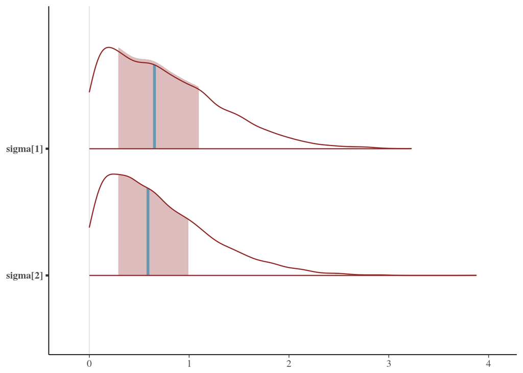

```r
post_draws_4 <- as.matrix(fit4, pars = c('sigma'))

mcmc_areas(post_draws_4)
```